# Varbench

Meltem Gürel

2017-02-03

**Varbench** is a suite of tools developed to compare somatic variant callers for targeted deep sequencing data, run the best performing one, and report the allele frequencies of the called variants using estimate intervals.

**Varbench** comprises four pipelines, namely **simulate**, **compare**, **estimate** and **validate**. This report briefly describes each pipeline and reports the results obtained by running them on targeted deep sequencing ctDNA data.

# *simulate*: Simulating somatic mutations

Given a sample .bam file and a reference genome `simulate` will induce somatic mutations to create a normal-tumour sample pair. The given .bam file is partitioned into halves where one is kept as the NORMAL.bam and the other is submitted to Bamsurgeon; a tool for adding mutations to .bam files. The mutation spots and the allele frequency is chosen based on a beta distribution which we believe best reflects ctDNA mutation distributions. *Figure 1* shows the pipeline flow.

[figure not shown]

Figure 1: simulate DAG

All of the pipelines can be configured via their respective configuration files - `congif.<pipe>.yml`. You can find these files in the `config` directory.

After you edit `config.simulate.yml` to specify the

- path to the reference genome file (`REFERENCE`),
- path to the paired-end .fastq read files (`SAMPLE1` and `SAMPLE2`),
- minimum and maximum coverage depth to filter reads (`MINDEPTH` and `MAXDEPTH`, default is 10 and 10K),
- directory to store the pipeline outputs (`OUT_DIR`, will be created if it doesn’t exist already),
- number of processes to use (`NTHREADS`)

run `simulate` with

```bash
$ snakemake --snakefile simulate --configfile config.simulate.yml
```

## Results

### Setup

- **input reads:** `SLX-10378.s_1.r_1.fq`, `SLX-10378.s_1.r_2.fq`
- **input genome:** hg19
- **command:** `snakemake --snakefile simulate --configfile config.simulate.yml`

### Read alignment

**ALIGNED SAMPLE STATS**  
*bwa-mem paired-end read alignment*

```
466165 + 0 in total (QC-passed reads + QC-failed reads)
0 + 0 secondary
0 + 0 supplementary
0 + 0 duplicates
466165 + 0 mapped (100.00% : N/A)
466165 + 0 paired in sequencing
233740 + 0 read1
232425 + 0 read2
463222 + 0 properly paired (99.37% : N/A)
464814 + 0 with itself and mate mapped
1351 + 0 singletons (0.29% : N/A)
1290 + 0 with mate mapped to a different chr
133 + 0 with mate mapped to a different chr (mapQ>=5)
```

### Alignment partitioning

**NORMAL SAMPLE STATS**  
*aligned read partitioned into two, 1/2 taken as the normal*

```
233118 + 0 in total (QC-passed reads + QC-failed reads)
0 + 0 secondary
0 + 0 supplementary
0 + 0 duplicates
233118 + 0 mapped (100.00% : N/A)
233118 + 0 paired in sequencing
116872 + 0 read1
116246 + 0 read2
231726 + 0 properly paired (99.40% : N/A)
232478 + 0 with itself and mate mapped
640 + 0 singletons (0.27% : N/A)
610 + 0 with mate mapped to a different chr
58 + 0 with mate mapped to a different chr (mapQ>=5)
```

**TUMOR SAMPLE BEFORE MODIFICATION STATS**  
*remaining 1/2 taken as the tumor template*

```
233047 + 0 in total (QC-passed reads + QC-failed reads)
0 + 0 secondary
0 + 0 supplementary
0 + 0 duplicates
233047 + 0 mapped (100.00% : N/A)
233047 + 0 paired in sequencing
116868 + 0 read1
116179 + 0 read2
231496 + 0 properly paired (99.33% : N/A)
232336 + 0 with itself and mate mapped
711 + 0 singletons (0.31% : N/A)
680 + 0 with mate mapped to a different chr
75 + 0 with mate mapped to a different chr (mapQ>=5)
```

### Inducing mutations

*hotspots every 100bp windows starting at a random origin*  
*allele frequencies chosen from a beta distribution with $\alpha$=2 and $\beta$=5*  
*range scaled and shifted to `[0.001-0.3]`*  
*RVAF: requested variant allele frequency*

```
##      CHR     POS  COV REF ALT   RVAF
## 1  chr17 7573012 5091   T   C 0.0946
## 2  chr17 7573985 5098   A   C 0.1060
## 3  chr17 7576855 6417   G   T 0.2020
## 4  chr17 7577115 6586   A   C 0.1340
## 5  chr17 7577564 5105   G   A 0.0493
## 6  chr17 7577665 6126   A   T 0.0512
## 7  chr17 7578231 5188   C   G 0.1410
## 8  chr17 7578421 5962   G   T 0.0553
## 9  chr17 7578422 5963   T   C 0.1550
## 10 chr17 7578554 6381   A   T 0.1610
## 11 chr17 7579357 4518   A   G 0.0359
## 12 chr17 7579537 8465   A   C 0.1910
## 13 chr17 7579710 5284   T   A 0.1180
## 14 chr17 7579860 4503   G   C 0.1460
```

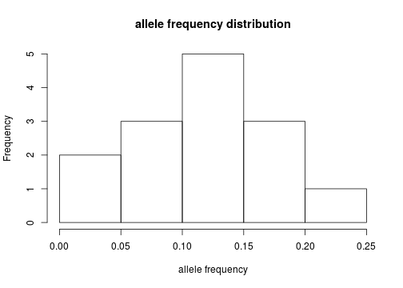

Figure 2: Requested allele frequency histogram

**TUMOUR SAMPLE AFTER MODIFICATION STATS**  
*tumour sample generated by inducing synthetic mutations with Bamsurgeon*

```
233047 + 0 in total (QC-passed reads + QC-failed reads)
0 + 0 secondary
0 + 0 supplementary
0 + 0 duplicates
164767 + 0 mapped (70.70% : N/A)
233047 + 0 paired in sequencing
116868 + 0 read1
116179 + 0 read2
146562 + 0 properly paired (62.89% : N/A)
159990 + 0 with itself and mate mapped
4777 + 0 singletons (2.05% : N/A)
674 + 0 with mate mapped to a different chr
70 + 0 with mate mapped to a different chr (mapQ>=5)
```

*AVAF: actual variant allele frequency induced by Bamsurgeon*

```r
mutations <- read.table("run1/simulate/SLX-10378.s_1.r_1.mutations.txt", header = TRUE)
mutations
```

```
##      CHR     POS  COV REF ALT   RVAF     AVAF
## 1  chr17 7573012 5226   T   C 0.0946 0.002870
## 2  chr17 7573985 5027   A   C 0.1060 0.001990
## 3  chr17 7576855 6295   G   T 0.2020 0.201000
## 4  chr17 7577115 3376   A   C 0.1340 0.000296
## 5  chr17 7577564 5153   G   A 0.0493 0.046200
## 6  chr17 7577665 5828   A   T 0.0512 0.000000
## 7  chr17 7578231 4300   C   G 0.1410 0.000698
## 8  chr17 7578421 2031   G   T 0.0553 0.000492
## 9  chr17 7578422 2031   T   C 0.1550 0.031500
## 10 chr17 7578554   27   A   T 0.1610 0.111000
## 11 chr17 7579357 4357   A   G 0.0359 0.039000
## 12 chr17 7579537 8154   A   C 0.1910 0.190000
## 13 chr17 7579710   10   T   A 0.1180 0.000000
## 14 chr17 7579860   14   G   C 0.1460 0.071400
```

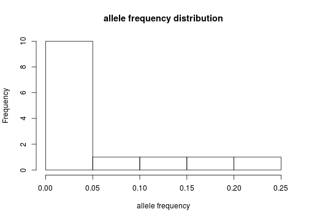

Figure 3: Actual allele frequency histogram

### Output

```r
# reports
list.files("run1/simulate/", pattern = "*.txt", full.names = TRUE)
```

```
## [1] "run1/simulate//readStats.txt"
## [2] "run1/simulate//report.txt"
## [3] "run1/simulate//SLX-10378.s_1.r_1.mutations.txt"
## [4] "run1/simulate//SLX-10378.s_1.r_1.originals.txt"
```

```r
# normal and tumor samples
list.files("run1/simulate/", pattern = "*bam*", full.names = TRUE)
```

```
## character(0)
```

```r
# RVAF histogram
list.files("run1/simulate/", pattern = "*.pdf", full.names = TRUE)
```

```
## [1] "run1/simulate//SLX-10378.s_1.r_1.mutations.freq.pdf"
```

# *compare*: Pick the best variant caller

With `compare` you can pick the best somatic variant caller for your data by comparing their $R^2$ for called and actual allele frequencies. *Figure 4* shows the pipeline flow.

[figure not shown]

Figure 4: compare DAG

To run `compare` you will need to install VarDict and SomaticSniper. These are already included in the conda environment. If, instead, you manually installed the dependencies please make sure to install these variant callers before you run `compare`. More variant callers will soon be integrated into **Varbench**.

`config.compare.yml` needs to be edited before running `compare`. Here the `NORMAL` and `TUMOUR` samples are the .bam files created with the `simulate` pipeline, and the `MUTATIONS` parameter refers to the list of mutations generated again with the same pipeline.

You also need to submit the

- path to the reference genome file (`REFERENCE`),
- directory to store the pipeline outputs (`OUT_DIR`, will be created if it doesn’t exist already),
- number of processes to split into (`NTHREADS`)

To run `compare` issue

```bash
snakemake --snakefile compare --configfile config.compare.yml
```

in your terminal.

### Setup

- **input samples:** `SLX-10378.s_1.r_1.normal.bam`, `SLX-10378.s_1.r_1.tumour.bam`
- **input genome:** hg19
- **hotspots:** `SLX-10378.s_1.r_1.mutations.txt`
- **command:** `snakemake --snakefile compare --configfile config.compare.yml`

### Quality metrics

**Vardict**

```
            precision   recall  F-score   Rsq
summ.mean   0.00661     0.524   0.0131    0.715
summ.sd     0.00068     0.0545  0.00134   0.062
```

**SomaticSniper**

```
            precision   recall  F-score   Rsq
summ.mean   0.0341      0.334   0.0618    0.234
summ.sd     0.00221     0.0084  0.00367   0.0398
```

#### $R^2$ distributions

**Vardict**

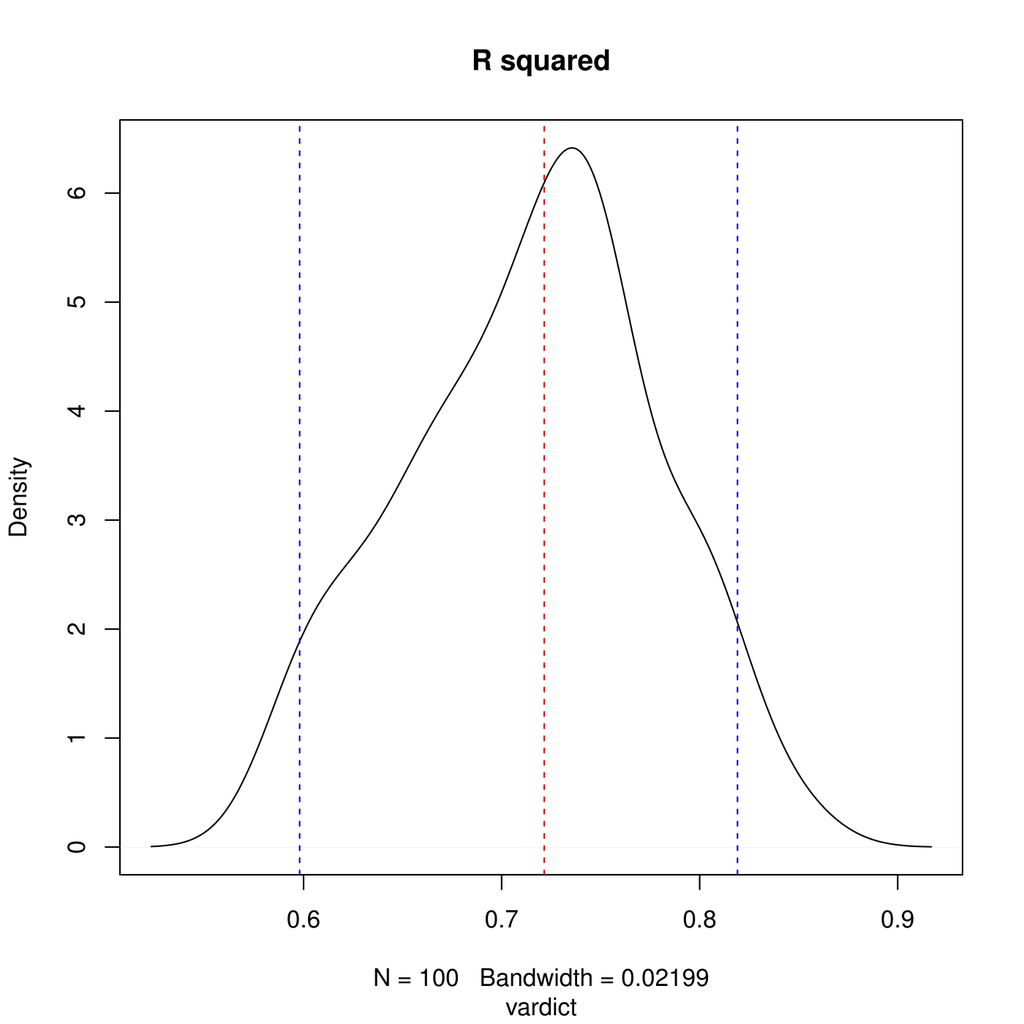

Figure 5: r2 distributions with vardict

**SomaticSniper**

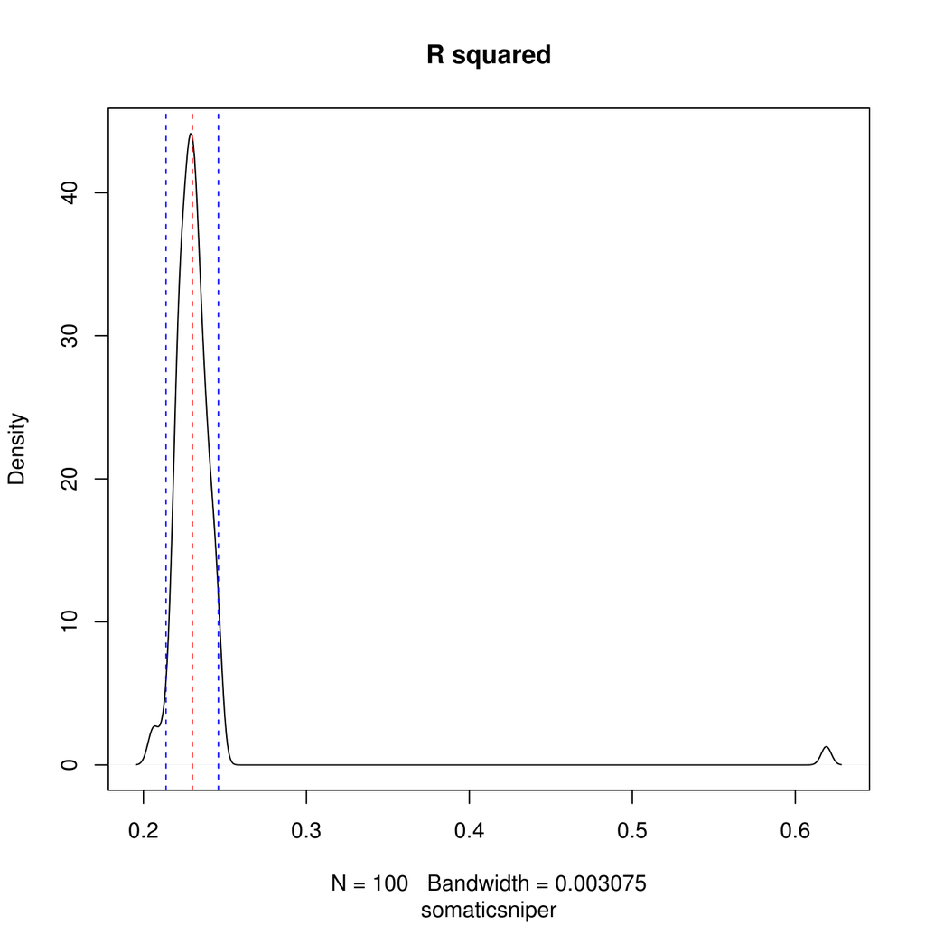

Figure 6: r2 distributions with somaticsniper

#### Allele frequency distributions

**Vardict**

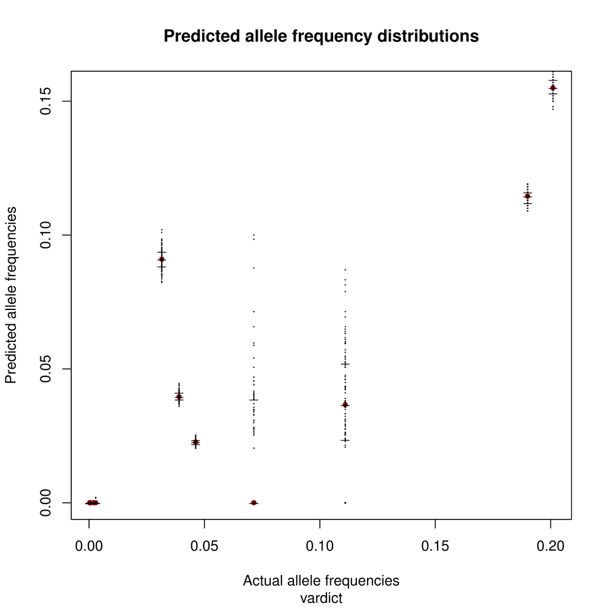

Figure 7: AF distributions with vardict

**SomaticSniper**

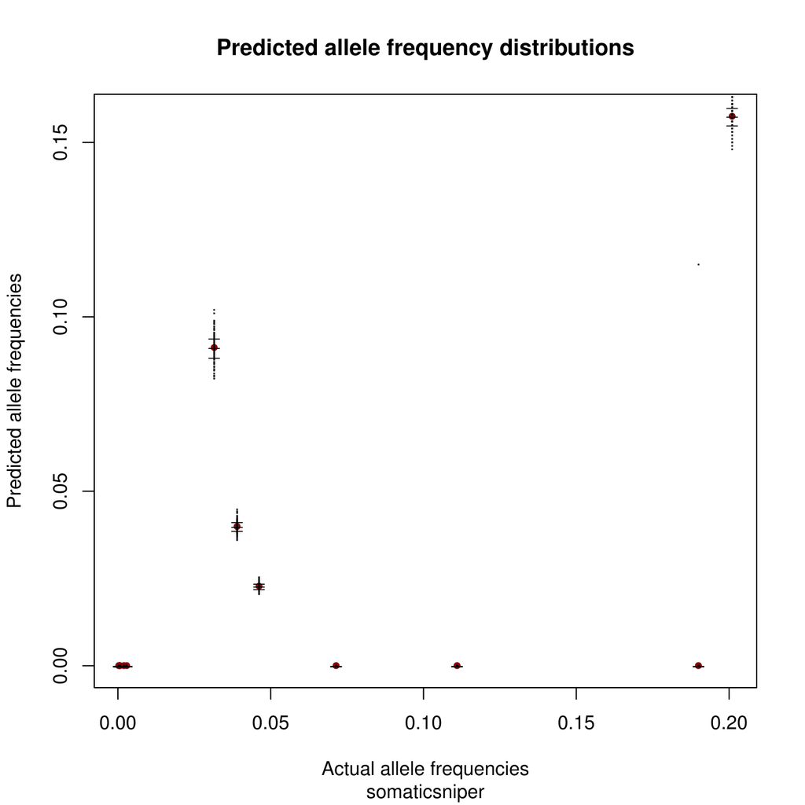

Figure 8: AF distributions with somaticsniper

### Output

```r
# reports
list.files("run1/compare/analysis", pattern = "*.txt", full.names = TRUE)
```

```
## [1] "run1/compare/analysis/results.txt"
```

```r
# plots
list.files("run1/compare/analysis", pattern = "*.pdf", full.names = TRUE)
```

```
##  [1] "run1/compare/analysis/afcorr_somaticsniper.pdf"
##  [2] "run1/compare/analysis/afcorr_vardict.pdf"
##  [3] "run1/compare/analysis/afdist_somaticsniper.pdf"
##  [4] "run1/compare/analysis/afdist_vardict.pdf"
##  [5] "run1/compare/analysis/fscore_somaticsniper.pdf"
##  [6] "run1/compare/analysis/fscore_vardict.pdf"
##  [7] "run1/compare/analysis/precision_somaticsniper.pdf"
##  [8] "run1/compare/analysis/precision_vardict.pdf"
##  [9] "run1/compare/analysis/r2_somaticsniper.pdf"
## [10] "run1/compare/analysis/r2_vardict.pdf"
## [11] "run1/compare/analysis/recall_somaticsniper.pdf"
## [12] "run1/compare/analysis/recall_vardict.pdf"
```

# *estimate*: Calling somatic mutations with allele frequency confidence intervals

Instead of reporting point estimates of allelic frequencies, `estimate` returns a list of somatic variants - called with the chosen software - with their interval estimates of allele frequencies. This measure provides a degree of confidence for the called variant. *Figure 9* shows the pipeline flow.

[figure not shown]

Figure 9: estimate DAG

`estimate` requires at least one of VarDict or SomaticSniper to be installed. And you must specify either ‘vardict’ or ‘somaticsniper’ as the preferred `CALLER` in the `config.estimate.yml` configuration file. Example setup files are provided in the root directory: `config.estimate_vardict.yml` and `config.estimate_somaticsniper.yml`. The `NORMAL` and `TUMOUR` samples are the .bam files created with the `simulate` pipeline.

Also specify the

- path to the reference genome file (`REFERENCE`),
- directory to store the pipeline outputs (`OUT_DIR`, will be created if it doesn’t exist already),
- number of processes to split into (`NTHREADS`)

`estimate` can then be executed with:

```bash
snakemake --snakefile estimate --configfile config.estimate.yml
```

### Setup

- **input samples:** SLX-10378.s_1.r_1.normal.bam, SLX-10378.s_1.r_1.tumour.bam
- **input genome:** hg19
- **caller:** Vardict, SomaticSniper (others will be added)
- **command:** `snakemake --snakefile estimate --configfile config.estimate_<caller>.yml`

### Bootstrap Summary

```r
mutations.vardict <- droplevels(subset(read.table("run1/estimate_vardict/analysis/results.txt",
    header = TRUE), median.allele.freq > 0))
head(mutations.vardict)
```

```
##      CHR      POS REF ALT median.allele.freq lower.bound upper.bound
## 2   chr1 36303056   T   G            0.00368     0.00000     0.00745
## 3   chr1 36303057   G   A            0.00783     0.00383     0.01430
## 6  chr17  7572910   A   G            0.00115     0.00000     0.00194
## 7  chr17  7572911   C   T            0.00116     0.00000     0.00193
## 9  chr17  7572913   A   G            0.00234     0.00149     0.00321
## 10 chr17  7572915   A   G            0.00369     0.00257     0.00507
```

```r
mutations.somaticsniper <- droplevels(subset(read.table("run1/estimate_somaticsniper/analysis/results.txt",
    header = TRUE), median.allele.freq > 0))
head(mutations.somaticsniper)
```

```
##      CHR      POS REF ALT median.allele.freq lower.bound upper.bound
## 1   chr1 20295541   c   T            1.00000           0     1.00000
## 12 chr16 89190195   A   G            0.10000           0     0.69200
## 31 chr17  7572948   T   C            0.00512           0     0.00703
## 32 chr17  7572950   T   C            0.00608           0     0.00800
## 63 chr17  7573923   T   C            0.00304           0     0.00468
## 64 chr17  7573925   A   G            0.00498           0     0.00711
```

### Output

```r
# reports
list.files("run1/estimate_vardict/analysis", pattern = "*.txt", full.names = TRUE)
```

```
## [1] "run1/estimate_vardict/analysis/results.txt"
```

```r
list.files("run1/estimate_somaticsniper/analysis", pattern = "*.txt", full.names = TRUE)
```

```
## [1] "run1/estimate_somaticsniper/analysis/results.txt"
```

```r
# plots
list.files("run1/estimate_vardict/analysis", pattern = "*.pdf", full.names = TRUE)
```

```
## [1] "run1/estimate_vardict/analysis/afdensities.pdf"
```

```r
list.files("run1/estimate_somaticsniper/analysis", pattern = "*.pdf", full.names = TRUE)
```

```
## [1] "run1/estimate_somaticsniper/analysis/afdensities.pdf"
```

# *validate*: Pick mutations for validation

When you create .VCF files with either `compare` or `estimate` you can run

```bash
snakemake --snakefile validate --configfile config.validate.yml
```

to receive a list of mutations you can use to validate the chosen variant caller’s accuracy. The returned list comprises `NMUTATIONS` number of mutations that were picked uniformly among all the called mutations after ordering them by their coefficient of variation. *Figure 10* shows the pipeline flow.

[figure not shown]

Figure 10: validate DAG

The `VCF_DIR` parameter in the `config.validate.yml` should point to the .VCF files and `NMUTATIONS` refers to the number of mutations you wish to validate.

Other required fields are the

- directory to store the pipeline outputs (`OUT_DIR`, will be created if it doesn’t exist already),
- the variant caller used to generate the .VCF files (`CALLER`)
- number of processes to split into (`NTHREADS`)

### Setup

- **input VCFs:** Bootstrap generated VCF files (generated with `compare` or `estimate`)
- **number of mutations to validate:** 20
- **caller:** Vardict, SomaticSniper (others will be added)
- **command:** `snakemake --snakefile validate --configfile config.validate_<caller>.yml`

### Output - List of mutations to validate (n=20)

**Vardict**

```r
mutations.vardict <- read.table("run1/validate_vardict/analysis/results.txt",
    header = TRUE)
mutations.vardict
```

```
##      CHR     POS REF ALT coef.variation standart.dev median.allele.freq
## 1  chr17 7578524   G   A        0.00513     0.004890           0.952000
## 2  chr17 7579592   T   C        0.10200     0.000714           0.007000
## 3  chr17 7577586   A   G        0.11300     0.000354           0.003140
## 4  chr17 7576834   A   G        0.12400     0.000652           0.005280
## 5  chr17 7577594   A   G        0.13300     0.000308           0.002300
## 6  chr17 7578175   A   G        0.14400     0.000977           0.006780
## 7  chr17 7574041   A   G        0.15300     0.000640           0.004180
## 8  chr17 7578259   A   G        0.16700     0.000803           0.004800
## 9  chr17 7574058   A   G        0.18400     0.000360           0.001960
## 10 chr17 7578280   G   A        0.20100     0.000587           0.002920
## 11 chr17 7576824   A   G        0.22500     0.000830           0.003680
## 12 chr17 7579334   G   A        0.25200     0.000573           0.002280
## 13 chr17 7573945   C   T        0.28900     0.000550           0.001900
## 14 chr17 7578147   C   T        0.33900     0.000588           0.001740
```

[output cut: 27 more lines]

**SomaticSniper**

```r
mutations.somaticsniper <- read.table("run1/validate_somaticsniper/analysis/results.txt",
    header = TRUE)
mutations.somaticsniper
```

```
##      CHR     POS REF ALT coef.variation standart.dev median.allele.freq
## 1  chr17 7577118   C   A        0.00330      0.00316            0.95700
## 2  chr17 7578401   G   T        0.00392      0.00380            0.96800
## 3  chr17 7578400   G   T        0.02760      0.01030            0.37400
## 4  chr17 7578422   T   C        0.04450      0.00406            0.09120
## 5  chr17 7578526   C   A        0.10100      0.07540            0.74900
## 6  chr17 7577642   T   C        0.39200      0.00197            0.00503
## 7  chr17 7579363   A   G        0.42300      0.00202            0.00478
## 8  chr17 7576894   G   A        0.43800      0.00102            0.00232
## 9  chr17 7579529   C   T        0.46100      0.00108            0.00234
## 10 chr17 7579392   A   G        0.48600      0.00175            0.00361
## 11 chr17 7576857   A   G        0.49900      0.00264            0.00529
## 12 chr17 7579339   A   G        0.53400      0.00252            0.00472
## 13 chr17 7577581   A   G        0.55200      0.00152            0.00276
## 14 chr17 7573925   A   G        0.56800      0.00286            0.00503
```

[output cut: 27 more lines]

### Output

```r
# reports
list.files("run1/validate_vardict/analysis", pattern = "*.txt", full.names = TRUE)
```

```
## [1] "run1/validate_vardict/analysis/results.txt"
```

```r
list.files("run1/validate_somaticsniper/analysis", pattern = "*.txt", full.names = TRUE)
```

```
## [1] "run1/validate_somaticsniper/analysis/results.txt"
```

```r
# allele frequency density plots
list.files("run1/validate_vardict/analysis", pattern = "*.pdf", full.names = TRUE)
```

```
## [1] "run1/validate_vardict/analysis/afdensities.pdf"
```

```r
list.files("run1/validate_somaticsniper/analysis", pattern = "*.pdf", full.names = TRUE)
```

```
## [1] "run1/validate_somaticsniper/analysis/afdensities.pdf"
```

# Full Varbench execution:

```
snakemake --snakefile simulate
          --configfile config.simulate.yml;
snakemake --snakefile compare
          --configfile config.compare.yml;
snakemake --snakefile estimate
          --configfile config.estimate_vardict.yml;
snakemake --snakefile estimate
          --configfile config.estimate_somaticsniper.yml;
snakemake --snakefile validate
          --configfile config.validate_vardict.yml;
snakemake --snakefile validate
          --configfile config.validate_somaticsniper.yml;
```

# Runtimes

[figure not shown]

Figure 11: runtime for simulate

[figure not shown]

Figure 12: runtime for compare

[figure not shown]

Figure 13: runtime for estimate

[figure not shown]

Figure 14: runtime for validate